# Analyse_Releves_PP_final

# Modèle final pour interprétation

$$Detection Lynx \sim Type Piège + Type
Support + Période + (1 | Identité Microsite)$$

```r
modele_final = glmmTMB(
  DetectionLynx ~
    TypePiege +
    Support +
    PE +
    (1 | MS),
  data = Tidy_Releves_PP,
  family = binomial
)

# Résumé du modèle

summary(modele_final)
```

```
##  Family: binomial  ( logit )
## Formula:          DetectionLynx ~ TypePiege + Support + PE + (1 | MS)
## Data: Tidy_Releves_PP
##
##       AIC       BIC    logLik -2*log(L)  df.resid
##     267.7     305.3    -126.9     253.7      1582
##
## Random effects:
##
## Conditional model:
##  Groups Name        Variance Std.Dev.
##  MS     (Intercept) 1.757    1.325
## Number of obs: 1589, groups:  MS, 24
##
## Conditional model:
##                 Estimate Std. Error z value Pr(>|z|)
## (Intercept)      -4.1736     0.7991  -5.223 1.76e-07 ***
## TypePiegebrosse  -2.1491     0.8517  -2.523  0.01162 *
## SupportPiquet    -1.1259     0.5397  -2.086  0.03696 *
## SupportRocher    -2.6568     1.2454  -2.133  0.03290 *
## PE2               1.7416     0.5316   3.276  0.00105 **
## PE3               1.4307     0.5582   2.563  0.01038 *
## ---
## Signif. codes:  0 '***' 0.001 '**' 0.01 '*' 0.05 '.' 0.1 ' ' 1
```

```r
# Comparaison terme à terme pour la période

emmeans(modele_final, pairwise ~ PE)
```

```
## $emmeans
##  PE emmean    SE  df asymp.LCL asymp.UCL
##  1   -6.51 0.790 Inf     -8.06     -4.96
##  2   -4.77 0.683 Inf     -6.11     -3.43
##  3   -5.08 0.709 Inf     -6.47     -3.69
##
## Results are averaged over the levels of: TypePiege, Support
## Results are given on the logit (not the response) scale.
## Confidence level used: 0.95
##
## $contrasts
##  contrast  estimate    SE  df z.ratio p.value
##  PE1 - PE2   -1.742 0.532 Inf  -3.276  0.0030
##  PE1 - PE3   -1.431 0.558 Inf  -2.563  0.0280
##  PE2 - PE3    0.311 0.420 Inf   0.740  0.7397
##
## Results are averaged over the levels of: TypePiege, Support
## Results are given on the log odds ratio (not the response) scale.
## P value adjustment: tukey method for comparing a family of 3 estimates
```

```r
# Comparaison terme à terme pour le type de support

emmeans(modele_final, pairwise ~ Support)
```

```
## $emmeans
##  Support emmean    SE  df asymp.LCL asymp.UCL
##  Arbre    -4.19 0.658 Inf     -5.48     -2.90
##  Piquet   -5.32 0.569 Inf     -6.43     -4.20
##  Rocher   -6.85 1.270 Inf     -9.34     -4.35
##
## Results are averaged over the levels of: TypePiege, PE
## Results are given on the logit (not the response) scale.
## Confidence level used: 0.95
##
## $contrasts
##  contrast        estimate   SE  df z.ratio p.value
##  Arbre - Piquet      1.13 0.54 Inf   2.086  0.0927
##  Arbre - Rocher      2.66 1.25 Inf   2.133  0.0832
##  Piquet - Rocher     1.53 1.13 Inf   1.353  0.3658
##
## Results are averaged over the levels of: TypePiege, PE
## Results are given on the log odds ratio (not the response) scale.
## P value adjustment: tukey method for comparing a family of 3 estimates
```

```r
# Comparaison terme à terme pour le type de piège à poil

emmeans(modele_final, pairwise ~ TypePiege)
```

```
## $emmeans
##  TypePiege emmean    SE  df asymp.LCL asymp.UCL
##  barbele    -4.38 0.667 Inf     -5.69     -3.07
##  brosse     -6.53 0.899 Inf     -8.29     -4.76
##
## Results are averaged over the levels of: Support, PE
## Results are given on the logit (not the response) scale.
## Confidence level used: 0.95
##
## $contrasts
##  contrast         estimate    SE  df z.ratio p.value
##  barbele - brosse     2.15 0.852 Inf   2.523  0.0116
##
## Results are averaged over the levels of: Support, PE
## Results are given on the log odds ratio (not the response) scale.
```

On observe qu’il y a une différence significative entre la P1 et les 2 périodes P2 et P3, mais que celles-ci n’ont pas de différences significatives entre elles. De même, on observe pas de contraste significatif entre les différents type de support. Enfin, il y a une différence significative entre les pièges à poil en barbelé et en brosse.

On en déduit donc que les pièges à poil en barbelé sont les plus efficaces, et qu’il est préférable d’effectuer la récolte de poil pendant et après le rut.

On doit maintenant vérifier la qualité du modèle.

## Vérification du modèle

Pour vérifier la qualité de notre modèle final, on va mesure la surdispersion des données et les $R^2$ marginaux et conditionnels du modèle.

```r
## Calcul de la surdispersion

overdisp_fun(modele_final)
```

```
##        chisq        ratio          rdf            p
## 1548.2873324    0.9786898 1582.0000000    0.7230010
```

```r
## Calcul des R² du modèle

r2(modele_final)
```

```
## # R2 for Mixed Models
##
##   Conditional R2: 0.532
##      Marginal R2: 0.282
```

## Visualisation graphique des résultats

Calcul des prédictions du modèle final.

```r
## Calcul des prédictions pour la période

pred_PE = ggpredict(
  model = modele_final,
  terms = c(
    'PE'
    )
)
```

```
## You are calculating adjusted predictions on the population-level (i.e.
##   `type = "fixed"`) for a *generalized* linear mixed model.
##   This may produce biased estimates due to Jensen's inequality. Consider
##   setting `bias_correction = TRUE` to correct for this bias.
##   See also the documentation of the `bias_correction` argument.
```

```r
## prédictions pour le support

pred_Support = ggpredict(
  model = modele_final,
  terms = c(
    'Support'
    )
)

## prédictions pour le type de piège à poil

pred_TypePiege = ggpredict(
  model = modele_final,
  terms = c(
    'TypePiege'
    )
)


## Calculs des interactions

pred_TypePiege_PE = ggpredict(
  model = modele_final,
  terms = c(
    'TypePiege',
    'PE'
    )
)

pred_Support_PE = ggpredict(
  model = modele_final,
  terms = c(
    'Support',
    'PE'
    )
)

pred_TypePiege_Support = ggpredict(
  model = modele_final,
  terms = c(
    'TypePiege',
    'Support'
    )
)
```

Tracé des prédictions du modèle pour les effets fixes

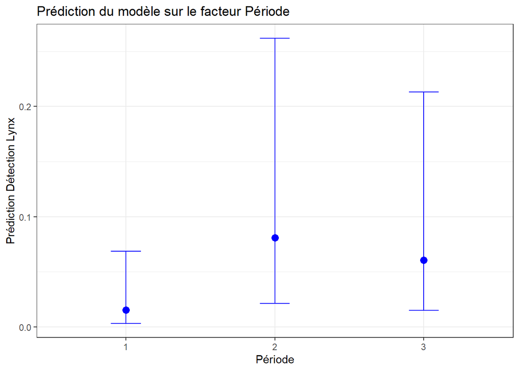

```r
## Plotting des données

# Période

ggplot(
  pred_PE,
  aes(
    x = x,
    y = predicted
    )
  ) +
  geom_point(
    size = 3,
    colour = "blue"
    ) +
  geom_errorbar(
    aes(
      ymin = conf.low,
      ymax = conf.high
      ),
    width = 0.2,
    colour = "blue"
    ) +
  labs(
    title = "Prédiction du modèle sur le facteur Période",
    x = "Période",
    y = "Prédiction Détection Lynx"
    ) +
  theme_bw()
```

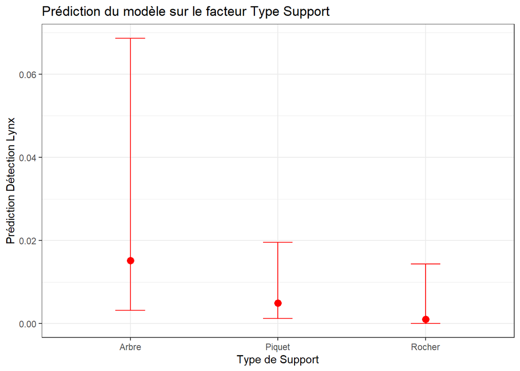

```r
ggsave(filename = "Plots/Prediction_Modele_PE.jpg")
# Support

ggplot(
  pred_Support,
  aes(
    x = x,
    y = predicted
    )
  ) +
  geom_point(
    size = 3,
    colour = "red"
    ) +
  geom_errorbar(
    aes(
      ymin = conf.low,
      ymax = conf.high
      ),
    width = 0.2,
    colour = "red"
    ) +
  labs(
    title = "Prédiction du modèle sur le facteur Type Support",
    x = "Type de Support",
    y = "Prédiction Détection Lynx"
    ) +
  theme_bw()
```

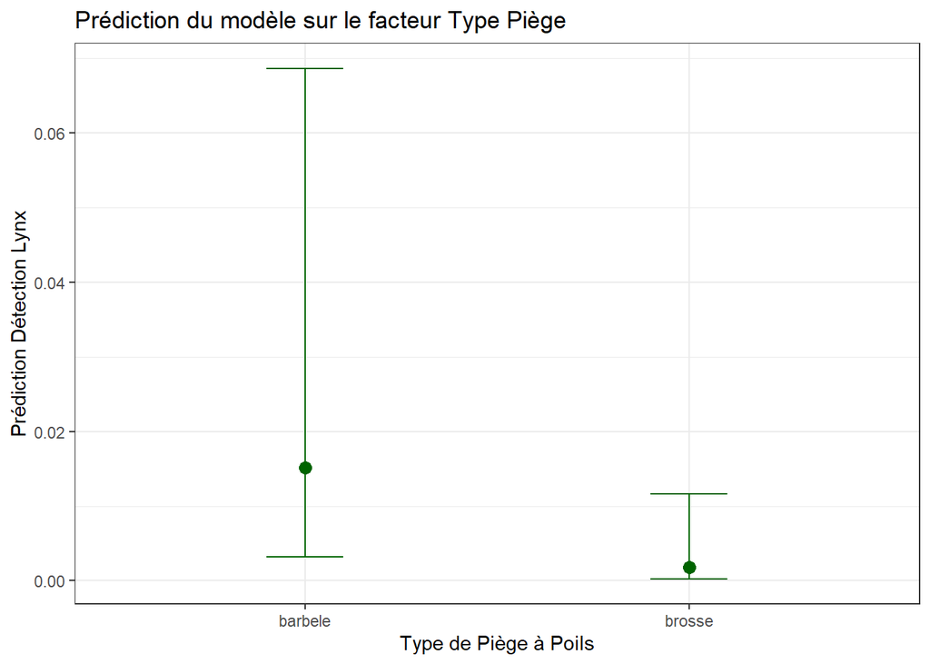

```r
ggsave(filename = "Plots/Prediction_Modele_Support.jpg")
# Type Piège

ggplot(
  pred_TypePiege,
  aes(
    x = x,
    y = predicted
    )
  ) +
  geom_point(
    size = 3,
    colour = "darkgreen"
    ) +
  geom_errorbar(
    aes(
      ymin = conf.low,
      ymax = conf.high
      ),
    width = 0.2,
    colour = "darkgreen"
    ) +
  labs(
    title = "Prédiction du modèle sur le facteur Type Piège",
    x = "Type de Piège à Poils",
    y = "Prédiction Détection Lynx"
    ) +
  theme_bw()
```

```r
ggsave(filename = "Plots/Prediction_Modele_TypePiege.jpg")
```

Tracé pour appréciation qualitative des intéractions entre les facteurs.

```r
# Calcul du modèle avec interaction

modele_final_interact = glmmTMB(
  DetectionLynx ~
    TypePiege +
    Support +
    PE +
    TypePiege:PE +
    Support:PE +
    TypePiege:Support +
    (1 | MS),
  data = Tidy_Releves_PP,
  family = binomial
)
summary(modele_final_interact)
```

```
##  Family: binomial  ( logit )
## Formula:
## DetectionLynx ~ TypePiege + Support + PE + TypePiege:PE + Support:PE +
##     TypePiege:Support + (1 | MS)
## Data: Tidy_Releves_PP
##
##       AIC       BIC    logLik -2*log(L)  df.resid
##     273.9     354.5    -122.0     243.9      1574
##
## Random effects:
##
## Conditional model:
##  Groups Name        Variance Std.Dev.
##  MS     (Intercept) 1.721    1.312
## Number of obs: 1589, groups:  MS, 24
##
## Conditional model:
##                                 Estimate Std. Error z value Pr(>|z|)
## (Intercept)                   -4.350e+00  1.054e+00  -4.129 3.64e-05 ***
## TypePiegebrosse               -8.699e-01  1.541e+00  -0.565   0.5724
## SupportPiquet                 -1.427e+00  1.147e+00  -1.244   0.2133
## SupportRocher                 -1.878e+01  8.922e+03  -0.002   0.9983
## PE2                            2.347e+00  9.780e-01   2.400   0.0164 *
## PE3                            1.335e+00  1.019e+00   1.309   0.1904
## TypePiegebrosse:PE2           -2.832e+01  3.947e+05   0.000   0.9999
## TypePiegebrosse:PE3           -1.214e+00  1.249e+00  -0.972   0.3310
## SupportPiquet:PE2             -1.059e-01  1.237e+00  -0.086   0.9318
## SupportRocher:PE2              1.646e+01  8.922e+03   0.002   0.9985
## SupportPiquet:PE3              6.453e-01  1.224e+00   0.527   0.5982
## SupportRocher:PE3             -1.188e+01  2.247e+06   0.000   1.0000
## TypePiegebrosse:SupportPiquet  5.432e-01  1.599e+00   0.340   0.7341
## TypePiegebrosse:SupportRocher -9.917e-01  5.691e+04   0.000   1.0000
## ---
## Signif. codes:  0 '***' 0.001 '**' 0.01 '*' 0.05 '.' 0.1 ' ' 1
```

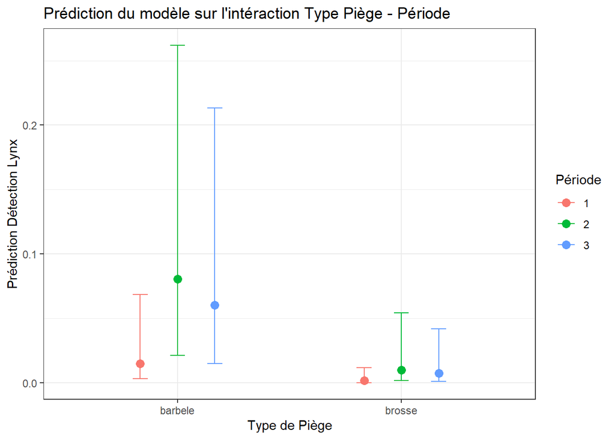

```r
# Interaction Type Piège - Période


ggplot(
  pred_TypePiege_PE,
  aes(
    x = x,
    y = predicted,
    colour = group
    )
  ) +
  geom_point(
    size = 3,
    position = position_dodge(width = 0.5)
    ) +
  geom_errorbar(
    aes(
      ymin = conf.low,
      ymax = conf.high
      ),
    width = 0.2,
    position = position_dodge(width = 0.5)
    ) +
  labs(
    title = "Prédiction du modèle sur l'intéraction Type Piège - Période",
    x = "Type de Piège",
    y = "Prédiction Détection Lynx",
    colour = "Période"
    ) +
  theme_bw()
```

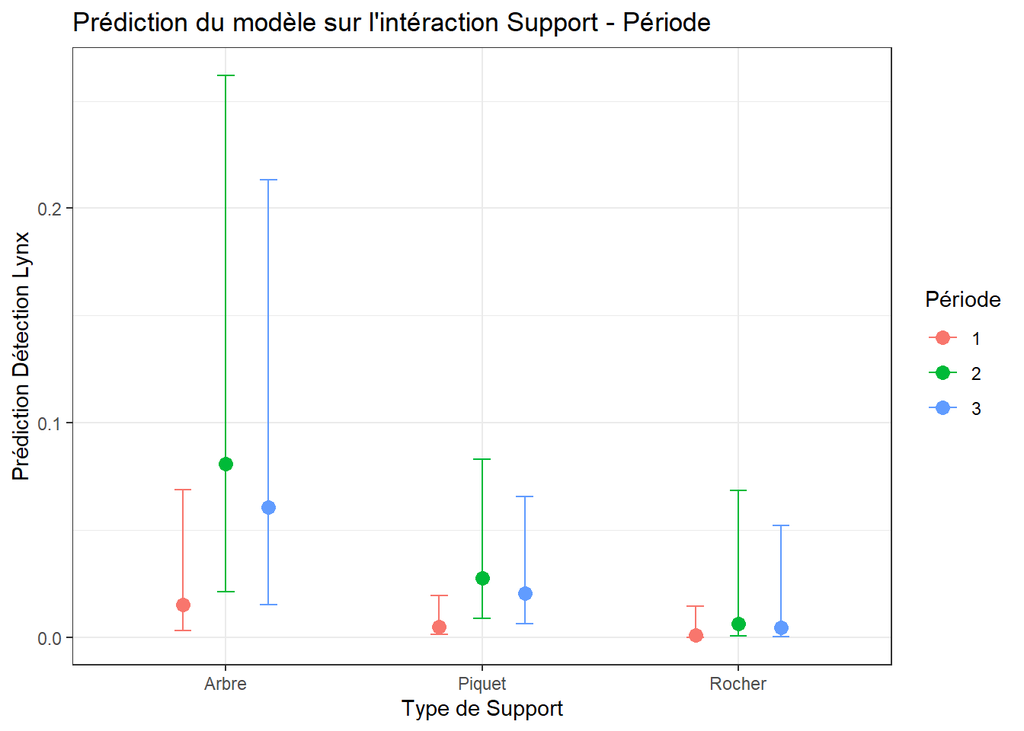

```r
ggsave(filename = "Plots/Interaction_TypePiege_PE.jpg")
# Support - Période


ggplot(
  pred_Support_PE,
  aes(
    x = x,
    y = predicted,
    colour = group
    )
  ) +
  geom_point(
    size = 3,
    position = position_dodge(width = 0.5)
    ) +
  geom_errorbar(
    aes(
      ymin = conf.low,
      ymax = conf.high
      ),
    width = 0.2,
    position = position_dodge(width = 0.5)
    ) +
  labs(
    title = "Prédiction du modèle sur l'intéraction Support - Période",
    x = "Type de Support",
    y = "Prédiction Détection Lynx",
    colour = "Période"
    ) +
  theme_bw()
```

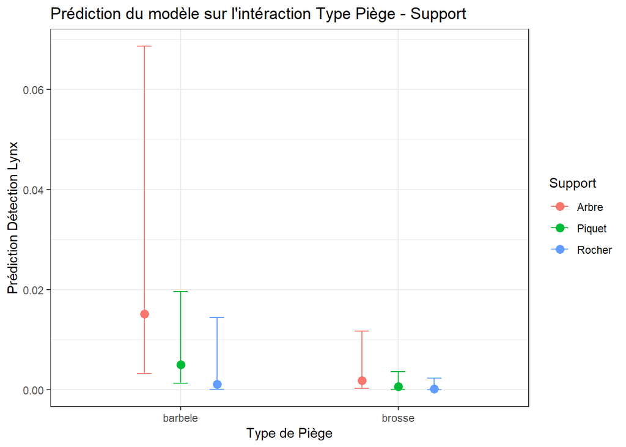

```r
ggsave(filename = "Plots/Interaction_Support_PE.jpg")
# Type Piège - Support


ggplot(
  pred_TypePiege_Support,
  aes(
    x = x,
    y = predicted,
    colour = group
    )
  ) +
  geom_point(
    size = 3,
    position = position_dodge(width = 0.5)
    ) +
  geom_errorbar(
    aes(
      ymin = conf.low,
      ymax = conf.high
      ),
    width = 0.2,
    position = position_dodge(width = 0.5)
    ) +
  labs(
    title = "Prédiction du modèle sur l'intéraction Type Piège - Support",
    x = "Type de Piège",
    y = "Prédiction Détection Lynx",
    colour = "Support"
    ) +
  theme_bw()
```

```r
ggsave(filename = "Plots/Interaction_TypePiege_Support.jpg")
```

On remarque une absence d’impact significatif des interactions. On en déduit donc que les interactions entre les effets fixes sont négligeables.

On en conclue donc que le modèle simplement additif est le bon.

# Conclusion

Le modèle final qui modélise nos données est
$$Detection Lynx \sim Type Piège + Type Support +
Période + (1 | Identité Microsite)$$
Ce modèle nous permet de conclure à un effet important de la période et du type de piège à poils. Il y a un léger effet du type de support, mais qui est plus faible (l’effet apparait comme significatif ou non selon les légères variations de modélisation).